# MTH6139 Time Series

Coursework 1 - 230239610

Abishek Pushpavinothan

16th March 2026

# Introduction

In this project I will be analysing Tesla’s (TLSA) stock prices using Meta’s Prophet forecasting system in R. All packages were installed in the console prior to knitting this document. The packages used are `prophet`, `quantmod`, `zoo`, and `dplyr`.

# Loading the data

I will be downloading Tesla’ stock data using the quantmod function in RStudio which is associated with Yahoo finance. This is the dataset I will be analysing during the project. I will use the quantmod function to abstract data from the 2023-2024 trading year and create a table with column heading “Date” and “Closing Prices”. This will allow me to fit the data into the prophet function later on.

```r
library(quantmod)
library(zoo)

getSymbols("TSLA", src = "yahoo", from = "2023-01-01", to = "2024-01-01")
```

```
## [1] "TSLA"
```

```r
tsla_prices <- Cl(TSLA)

tsla_readable <- data.frame(
  Date         = as.Date(index(tsla_prices)),
  ClosingPrice = as.numeric(tsla_prices))
```

# Inspecting the data

I will check head, tails and summary of the data to analyse the specifics of the data

```r
head(tsla_readable)
```

```
##         Date ClosingPrice
## 1 2023-01-03       108.10
## 2 2023-01-04       113.64
## 3 2023-01-05       110.34
## 4 2023-01-06       113.06
## 5 2023-01-09       119.77
## 6 2023-01-10       118.85
```

```r
tail(tsla_readable)
```

```
##           Date ClosingPrice
## 245 2023-12-21       254.50
## 246 2023-12-22       252.54
## 247 2023-12-26       256.61
## 248 2023-12-27       261.44
## 249 2023-12-28       253.18
## 250 2023-12-29       248.48
```

```r
summary(tsla_readable)
```

```
##       Date             ClosingPrice
##  Min.   :2023-01-03   Min.   :108.1
##  1st Qu.:2023-04-03   1st Qu.:186.1
##  Median :2023-07-04   Median :222.1
##  Mean   :2023-07-02   Mean   :217.5
##  3rd Qu.:2023-10-01   3rd Qu.:253.0
##  Max.   :2023-12-29   Max.   :293.3
```

We can see that trading opened on 3rd Jan 2023 with the stock around $108.10 and ends the trading year on 29th December 2023 at around $248.48, showing that Tesla more than doubled in stock value in a year. There was also a mean closing price of $217.50 and a median of $222.10, suggesting a roughly symmetric distribution and no extreme outliers skewing the average.

# Fitting the prophet model

Researching the prophet function has shown me that the dataframe must have columns labelled “ds” and “y” for a model to be fitted. Therefore, I will look to rename my columns before fitting the model. The model will show the long-run stock trend for the Tesla stock, so ignoring weekly and daily seasonality would make the trend clearer.

```r
library(prophet)
tsla_prophet_input <- data.frame(
  ds = tsla_readable$Date,
  y  = tsla_readable$ClosingPrice)

tslaModel <- prophet(
  tsla_prophet_input,
  yearly.seasonality = TRUE,
  weekly.seasonality = FALSE,
  daily.seasonality  = FALSE)
```

# Forecasting

In this section I will begin to forecast the data for the next 365 days beyond the original dataset using the make_future_dataframe and predict commands

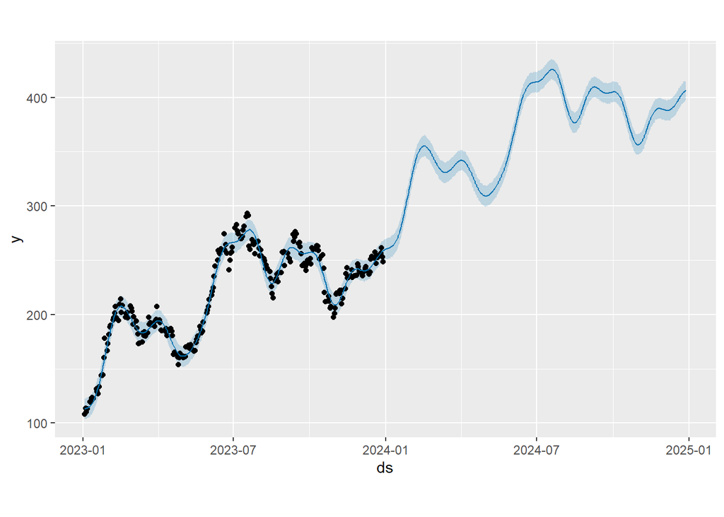

```r
tslaFutureDates <- make_future_dataframe(tslaModel, periods = 365)
tslaForecast    <- predict(tslaModel, tslaFutureDates)

plot(tslaModel, tslaForecast)
```

# Trend and Seasonality Components

When forecasting stock data, it is important to extract individual trend and seasonality components to check how much of an effect this has on the data.

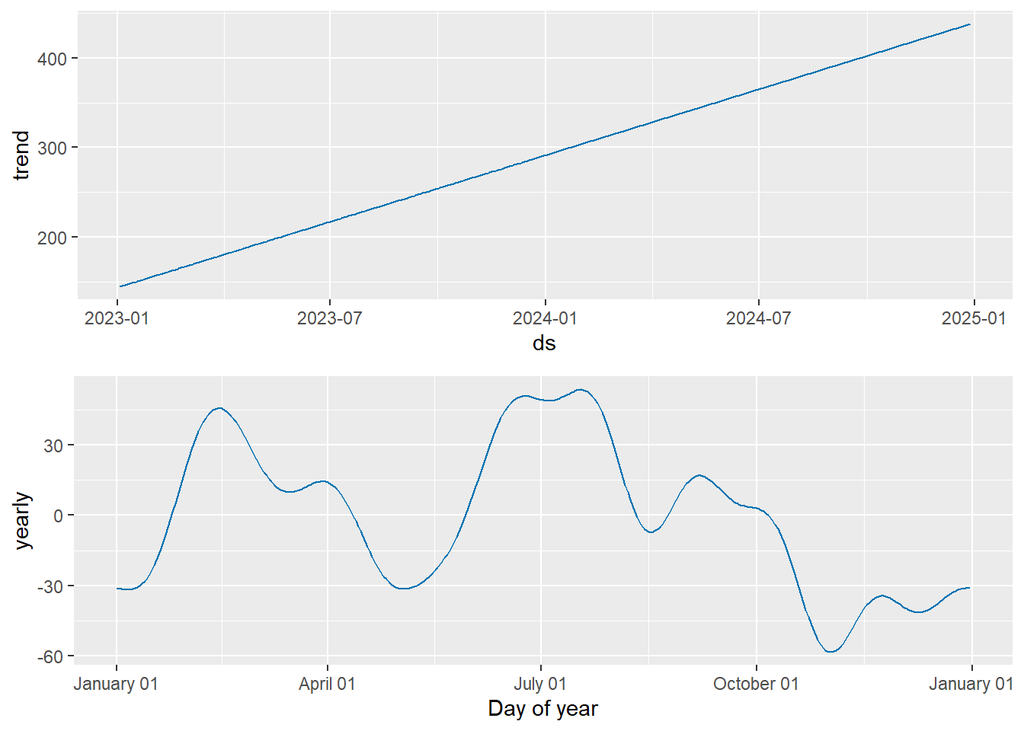

```r
prophet_plot_components(tslaModel, tslaForecast)
```

# Linear regression

To quantify the trend more precisely, I will fit a simple linear regression of closing price against a numeric time index.

```r
tsla_readable$TimeIndex <- as.numeric(tsla_readable$Date)

tslaLinearModel <- lm(ClosingPrice ~ TimeIndex, data = tsla_readable)
summary(tslaLinearModel)
```

```
##
## Call:
## lm(formula = ClosingPrice ~ TimeIndex, data = tsla_readable)
##
## Residuals:
##     Min      1Q  Median      3Q     Max
## -58.172 -23.240  -0.602  20.657  71.433
##
## Coefficients:
##               Estimate Std. Error t value Pr(>|t|)
## (Intercept) -5.329e+03  3.506e+02  -15.20   <2e-16 ***
## TimeIndex    2.838e-01  1.794e-02   15.82   <2e-16 ***
## ---
## Signif. codes:  0 '***' 0.001 '**' 0.01 '*' 0.05 '.' 0.1 ' ' 1
##
## Residual standard error: 29.63 on 248 degrees of freedom
## Multiple R-squared:  0.5023, Adjusted R-squared:  0.5003
## F-statistic: 250.3 on 1 and 248 DF,  p-value: < 2.2e-16
```

# Conclusion and assumptions

Forecasts may be misleading, especially with stock data that is sensitive to many factors such as geopolitics, supply contraints and developing consumer preferences. The trend growth forecasted shows a consistent linear pattern, however this should be treated with caution as Prophet extrapolates existing patterns forward and cannot account for unexpected events. Overall, this analysis demonstrates the capability of Meta’s Prophet as an accessible and powerful tool for time series forecasting, while also highlighting the inherent limitations of applying trend-based models to financial data.

# References

- Datacamp course: https://www.datacamp.com/courses/reporting-with-rmarkdown
- RStudio reference: https://rmarkdown.rstudio.com/lesson-1.html